# Replication

Minseo Brenda Kim

2025-05-01

## Paper Overview

I replicate the analysis in the paper “Multiscale patterns of rarity in fungi, inferred from fruiting records” by Gange et al. (2019) The study investigated whether fungi exhibit similar macroecological patterns of abundance and spatial distribution as other organisms. Specifically, the authors examined fungal abundance-occupancy relationships to determine if fungi that are common at a local scale tend to be more widely distributed at broader regional scales. The authors used datasets of fungal fruiting records from the UK and Switzerland, and there are four main types of analyses: Species abundance distributions (SADs), Rank abundance distributions (RADs), Abundance-occupancy relationships, and Multiscale indices of rarity.

For this replication, I will focus on three key analyses from the paper:

1. Species abundance distribution analysis (descriptive) - Figure 2 and 3
2. Abundance-occupancy relationship analysis (inferential) - Figure 5
3. Multiscale indices of rarity (inferential) - Figure 6

## Data Exploration

```r
> #load necessary libraries
> library(tidyverse)
> library(vegan)
> library(sads)
> library(mgcv)
> library(car)
> library(curl)
```

```
## Using libcurl 8.11.1 with OpenSSL/3.3.2
##
##
```

```r
> library(readr)
```

Since there are two sheets in Excel file, I separated them as UK_data.csv and Swiss_data.csv. (The original data were obtained from the Dryad (DOI: 10.5061/dryad.h36dj4t) and split into UK (2,319 species) and Swiss (319 species) datasets.)

count = abundance data grid = range data National = national data logit = logit transformation

Supplementry Table S1. Complete species list for the UK, with raw data showing abundance (number of records) and range (occupancy)

```r
> UK <- curl("https://raw.githubusercontent.com/msbrendakim/AN588-Replication/refs/heads/main/UK_data.csv")
> UK_data <- read_csv(UK)
```

```
## ──────────────────────────────────────────────────────── Delimiter: "," chr
## (1): ...1 dbl (10): count, log_count, grid_count, log_grid, FRDBI_count,
## log_FRDBI_cou... lgl (2): ...12, ...13
```

```r
> dim(UK_data)
```

```
## [1] 2319   13
```

```r
> anyNA(UK_data)
```

```
## [1] TRUE
```

```r
> summary(UK_data)
```

```
##      ...1               count          log_count        grid_count
##  Length:2319        Min.   :  1.00   Min.   :0.0000   Min.   :  1.00
##  Class :character   1st Qu.:  1.00   1st Qu.:0.0000   1st Qu.:  1.00
##  Mode  :character   Median :  4.00   Median :0.6021   Median :  3.00
##                     Mean   : 26.77   Mean   :0.7546   Mean   : 11.89
##                     3rd Qu.: 16.00   3rd Qu.:1.2041   3rd Qu.: 11.00
##                     Max.   :979.00   Max.   :2.9908   Max.   :190.00
##     log_grid       FRDBI_count      log_FRDBI_count   FRDBI_grid
##  Min.   :0.0000   Min.   :    1.0   Min.   :0.000   Min.   :   1.0
##  1st Qu.:0.0000   1st Qu.:   42.0   1st Qu.:1.623   1st Qu.:  23.0
##  Median :0.4771   Median :  147.0   Median :2.167   Median :  74.0
##  Mean   :0.6289   Mean   :  586.9   Mean   :2.147   Mean   : 182.3
##  3rd Qu.:1.0414   3rd Qu.:  505.0   3rd Qu.:2.703   3rd Qu.: 228.5
##  Max.   :2.2788   Max.   :14336.0   Max.   :4.156   Max.   :1637.0
##  log_FRDBI_grid    logit_grid      logit_FRDB_grid    ...12
##  Min.   :0.000   Min.   :-2.7875   Min.   :-3.3978   Mode:logical
##  1st Qu.:1.362   1st Qu.:-2.7875   1st Qu.:-2.0322   NA's:2319
##  Median :1.869   Median :-2.3089   Median :-1.5157
##  Mean   :1.829   Mean   :-2.1505   Mean   :-1.5325
##  3rd Qu.:2.359   3rd Qu.:-1.7389   3rd Qu.:-0.9974
##  Max.   :3.214   Max.   :-0.3486   Max.   : 0.2780
##   ...13
##  Mode:logical
##  NA's:2319
##
##
##
##
```

```r
> head(UK_data)
```

```
## # A tibble: 6 × 13
##   ...1           count log_count grid_count log_grid FRDBI_count log_FRDBI_count
##   <chr>          <dbl>     <dbl>      <dbl>    <dbl>       <dbl>           <dbl>
## 1 Abortiporus b…    10     1              8    0.903         905            2.96
## 2 Acanthonitsch…    14     1.15           6    0.778          51            1.71
## 3 Acrogenospora…     1     0              1    0              60            1.78
## 4 Acrospermum c…     5     0.699          5    0.699         295            2.47
## 5 Actinocladium…     2     0.301          2    0.301          60            1.78
## 6 Agaricus arve…   121     2.08          42    1.62         1544            3.19
## # ℹ 6 more variables: FRDBI_grid <dbl>, log_FRDBI_grid <dbl>, logit_grid <dbl>,
## #   logit_FRDB_grid <dbl>, ...12 <lgl>, ...13 <lgl>
```

Supplementry Table S2. Complete species list for Switzerland, with raw data showing abundance (number of records) and range (occupancy)

```r
> s <- curl("https://raw.githubusercontent.com/msbrendakim/AN588-Replication/refs/heads/main/Swiss_data.csv")
> Swiss_data <- read_csv(s)
```

```
## ──────────────────────────────────────────────────────── Delimiter: "," chr
## (1): ...1 dbl (8): count, log_count, National_count, log_National_count,
## National_grid... lgl (2): ...10, ...11
```

```r
> dim(Swiss_data)
```

```
## [1] 319  11
```

```r
> anyNA(Swiss_data)
```

```
## [1] TRUE
```

```r
> summary(Swiss_data)
```

```
##      ...1               count           log_count      National_count
##  Length:319         Min.   :    1.0   Min.   :0.0000   Min.   :   1.0
##  Class :character   1st Qu.:    4.0   1st Qu.:0.6021   1st Qu.:  41.0
##  Mode  :character   Median :   19.0   Median :1.2788   Median : 128.0
##                     Mean   :  304.1   Mean   :1.3771   Mean   : 195.0
##                     3rd Qu.:  104.5   3rd Qu.:2.0191   3rd Qu.: 279.5
##                     Max.   :12524.0   Max.   :4.0977   Max.   :1087.0
##  log_National_count National_grid    log_National_grid National_grid_p
##  Min.   :0.000      Min.   :  1.00   Min.   :0.000     Min.   :0.002141
##  1st Qu.:1.613      1st Qu.: 27.00   1st Qu.:1.431     1st Qu.:0.057816
##  Median :2.107      Median : 57.00   Median :1.756     Median :0.122056
##  Mean   :1.995      Mean   : 63.55   Mean   :1.646     Mean   :0.136078
##  3rd Qu.:2.446      3rd Qu.: 91.50   3rd Qu.:1.961     3rd Qu.:0.195932
##  Max.   :3.036      Max.   :220.00   Max.   :2.342     Max.   :0.471092
##  logit_National_grid  ...10          ...11
##  Min.   :-2.66839    Mode:logical   Mode:logical
##  1st Qu.:-1.21239    NA's:319       NA's:319
##  Median :-0.85691
##  Mean   :-0.95730
##  3rd Qu.:-0.61319
##  Max.   :-0.05027
```

```r
> head(Swiss_data)
```

```
## # A tibble: 6 × 11
##   ...1           count log_count National_count log_National_count National_grid
##   <chr>          <dbl>     <dbl>          <dbl>              <dbl>         <dbl>
## 1 Agaricus semo…    26     1.41              52               1.72            34
## 2 Agaricus sylv…    26     1.41             293               2.47            94
## 3 Agrocybe prae…     4     0.602            177               2.25            81
## 4 Amanita batta…     4     0.602            228               2.36            89
## 5 Amanita citri…   263     2.42             301               2.48            98
## 6 Amanita excel…    16     1.20             488               2.69           108
## # ℹ 5 more variables: log_National_grid <dbl>, National_grid_p <dbl>,
## #   logit_National_grid <dbl>, ...10 <lgl>, ...11 <lgl>
```

### Analysis 1: Species Abundance Distributions (SAD) (Figure 2 and 3)

##### UK National SAD

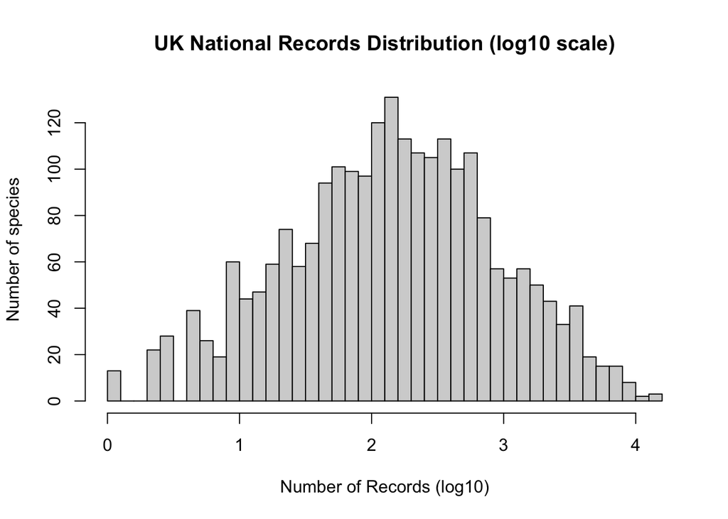

```r
> # UK National scale (Figure 2)
> hist(log10(UK_data$FRDBI_count), breaks = 30,
+      main = "UK National Records Distribution (log10 scale)",
+      xlab = "Number of Records (log10)",
+      ylab = "Number of species")
```

```r
> # Fit distributions to UK national data
> UK_nat_lnorm <- fitsad(UK_data$FRDBI_count, "lnorm")
> UK_nat_pareto <- fitsad(UK_data$FRDBI_count, "pareto")
> UK_nat_weibull <- fitsad(UK_data$FRDBI_count, "weibull")
>
> # Compare model fits using AIC
> UK_nat_aic <- AIC(UK_nat_lnorm, UK_nat_pareto, UK_nat_weibull)
> UK_nat_aic
```

```
##        AIC df
## 1 32323.19  2
## 2 34979.80  2
## 3 32517.17  2
```

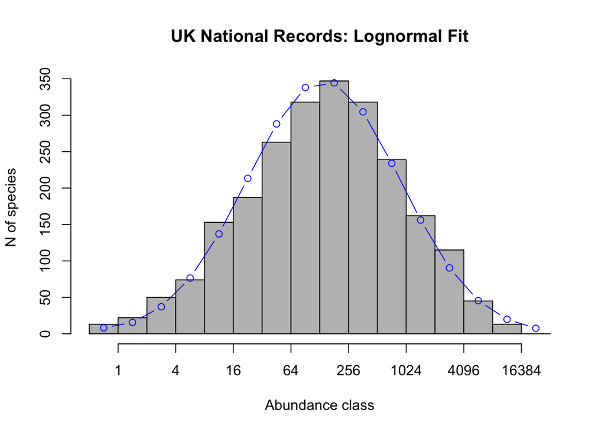

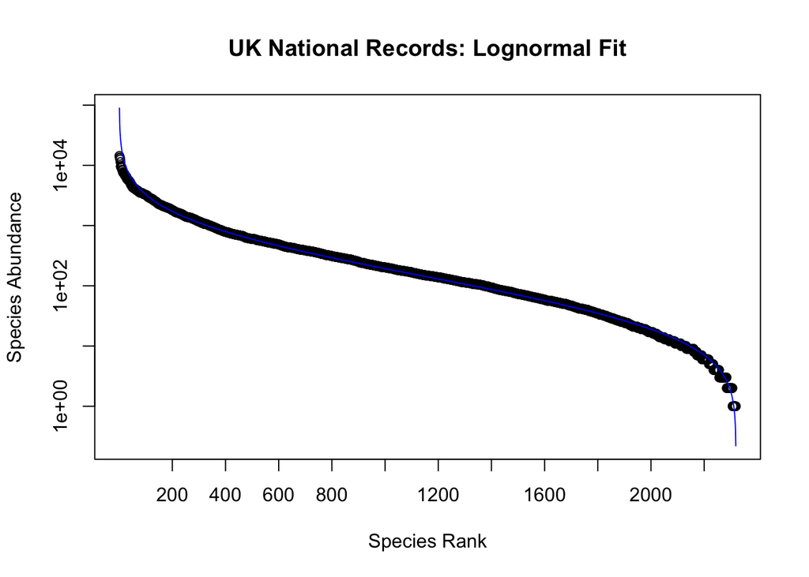

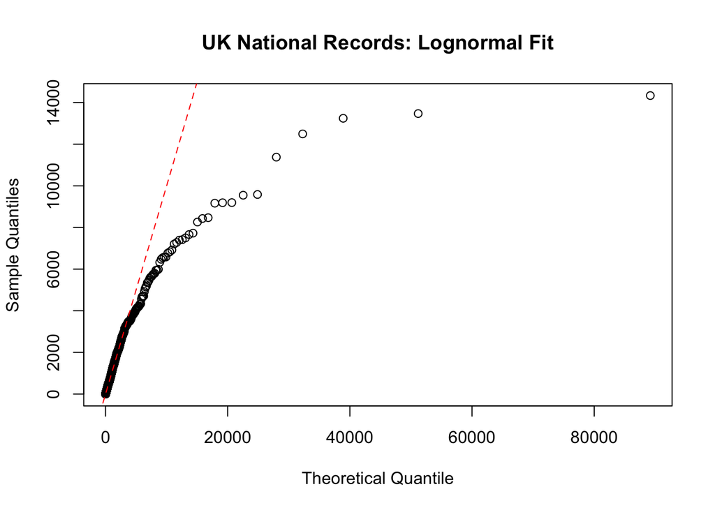

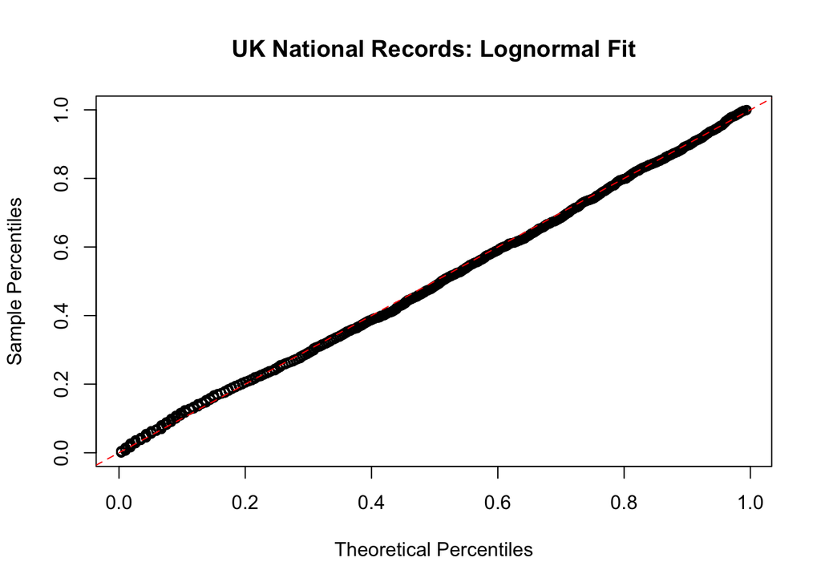

```r
> # Plot the best fitting distribution for national data
> plot(UK_nat_lnorm, main = "UK National Records: Lognormal Fit")
```

##### Original Figure

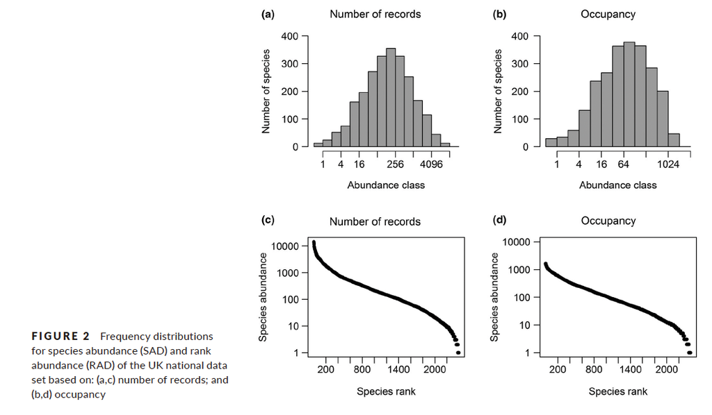

The UK national SAD was best fitted by a lognormal distribution with an AIC of 32323.19, compared to the paper’s 33,305.1.

##### UK Local SAD (Figure 3)

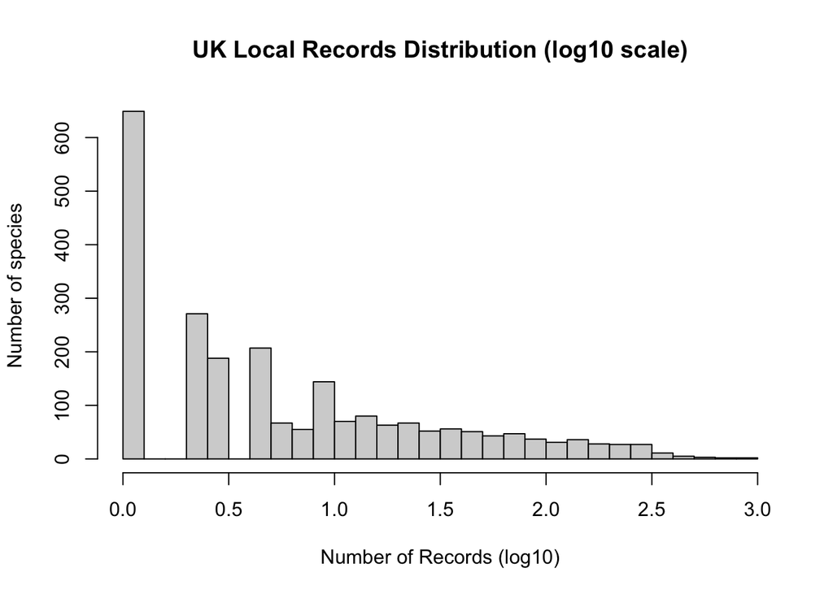

```r
> # UK Local scale - Species Abundance Distribution (Figure 3a)
> hist(log10(UK_data$count), breaks = 30,
+      main = "UK Local Records Distribution (log10 scale)",
+      xlab = "Number of Records (log10)",
+      ylab = "Number of species")
```

```r
> # Fit distributions to UK local data
> UK_loc_lnorm <- fitsad(UK_data$count, "lnorm")
> UK_loc_pareto <- fitsad(UK_data$count, "pareto")
> UK_loc_weibull <- fitsad(UK_data$count, "weibull")
>
> # Compare model fits using AIC
> UK_loc_aic <- AIC(UK_loc_lnorm, UK_loc_pareto, UK_loc_weibull)
> UK_loc_aic
```

```
##        AIC df
## 1 16931.75  2
## 2 15262.85  2
## 3 17661.33  2
```

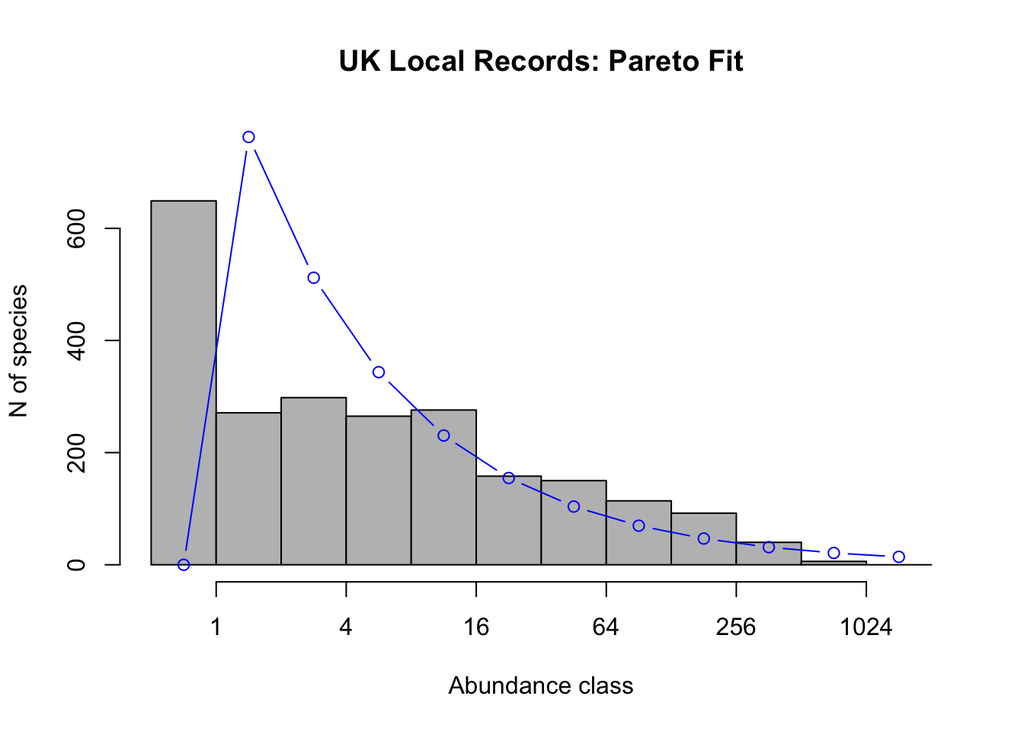

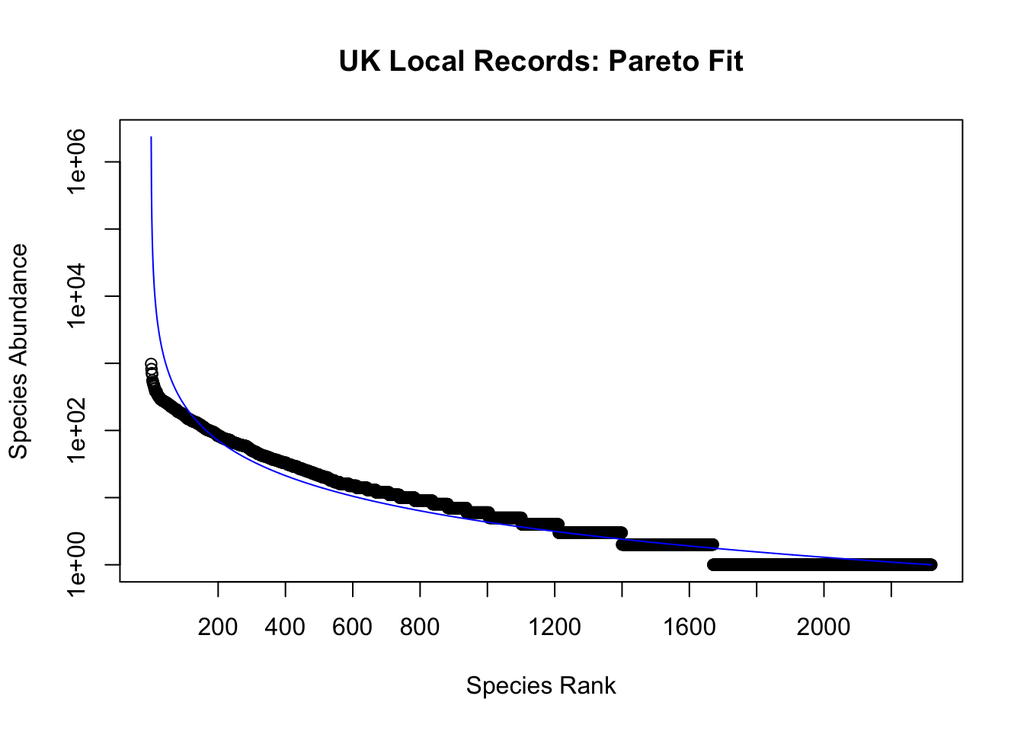

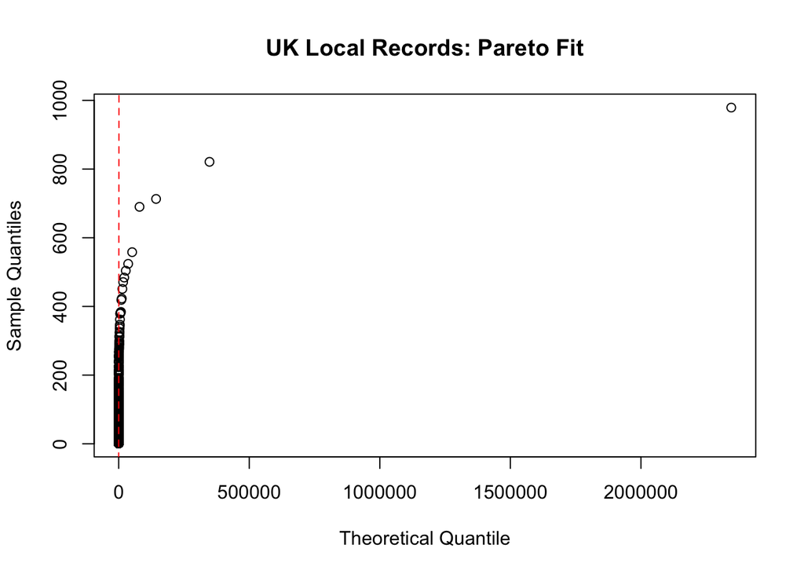

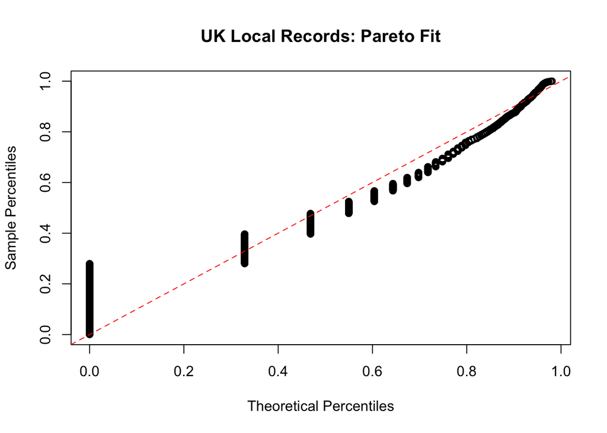

```r
> # Plot the best fitting distribution for local data
> plot(UK_loc_pareto, main = "UK Local Records: Pareto Fit")
```

##### Original Figure

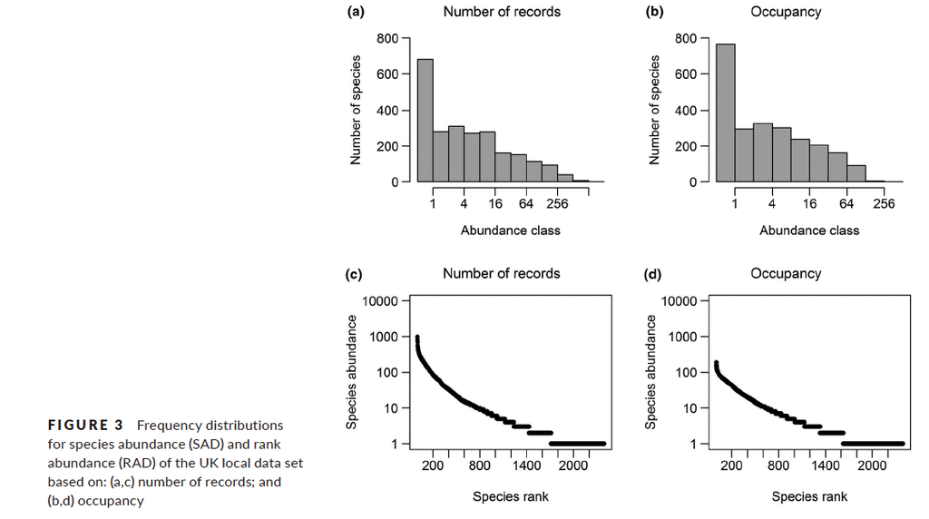

## Analysis 2: Abundance-Occupancy Relationships (Figure 5)

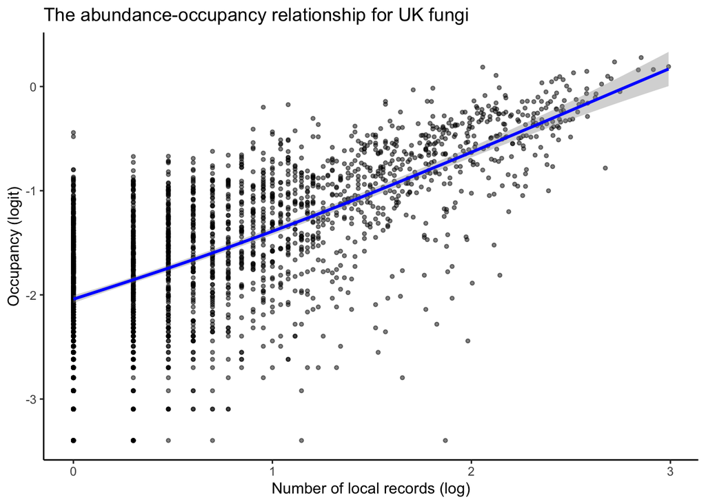

```r
> # Transform data as described in the paper
> UK_data$log_local_abundance <- log10(UK_data$count)
> UK_data$logit_national_occupancy <- UK_data$logit_FRDB_grid
>
> # Plot abundance-occupancy relationship for UK (Figure 5a)
> uk_ao_plot <- ggplot(UK_data, aes(x = log_local_abundance, y = logit_national_occupancy)) +
+   geom_point(alpha = 0.5, size = 1) +
+   geom_smooth(method = "gam", formula = y ~ s(x), color = "blue") +
+   labs(title = "The abundance-occupancy relationship for UK fungi",
+        x = "Number of local records (log)",
+        y = "Occupancy (logit)") +
+   theme_classic()
>
> print(uk_ao_plot)
```

```r
> # Linear model for UK
> UK_ao_linear <- lm(logit_national_occupancy ~ log_local_abundance, data = UK_data)
> summary(UK_ao_linear)
```

```
##
## Call:
## lm(formula = logit_national_occupancy ~ log_local_abundance,
##     data = UK_data)
##
## Residuals:
##      Min       1Q   Median       3Q      Max
## -2.65182 -0.31049  0.06376  0.35401  1.62330
##
## Coefficients:
##                     Estimate Std. Error t value Pr(>|t|)
## (Intercept)         -2.06501    0.01608 -128.43   <2e-16 ***
## log_local_abundance  0.70567    0.01551   45.51   <2e-16 ***
## ---
## Signif. codes:  0 '***' 0.001 '**' 0.01 '*' 0.05 '.' 0.1 ' ' 1
##
## Residual standard error: 0.5311 on 2317 degrees of freedom
## Multiple R-squared:  0.472,  Adjusted R-squared:  0.4718
## F-statistic:  2071 on 1 and 2317 DF,  p-value: < 2.2e-16
```

```r
> # Nonlinear model (GAM) for UK
> UK_ao_gam <- gam(logit_national_occupancy ~ s(log_local_abundance), data = UK_data)
> summary(UK_ao_gam)
```

```
##
## Family: gaussian
## Link function: identity
##
## Formula:
## logit_national_occupancy ~ s(log_local_abundance)
##
## Parametric coefficients:
##             Estimate Std. Error t value Pr(>|t|)
## (Intercept) -1.53252    0.01101  -139.2   <2e-16 ***
## ---
## Signif. codes:  0 '***' 0.001 '**' 0.01 '*' 0.05 '.' 0.1 ' ' 1
##
## Approximate significance of smooth terms:
##                          edf Ref.df     F p-value
## s(log_local_abundance) 2.086   2.59 804.5  <2e-16 ***
## ---
## Signif. codes:  0 '***' 0.001 '**' 0.01 '*' 0.05 '.' 0.1 ' ' 1
##
## R-sq.(adj) =  0.473   Deviance explained = 47.4%
## GCV = 0.28162  Scale est. = 0.28125   n = 2319
```

```r
> # Compare R² values for UK
> cat("UK Linear model R²:", summary(UK_ao_linear)$r.squared, "\n")
```

```
## UK Linear model R²: 0.4720087
```

```r
> cat("UK GAM model R²:", summary(UK_ao_gam)$r.sq, "\n")
```

```
## UK GAM model R²: 0.4732928
```

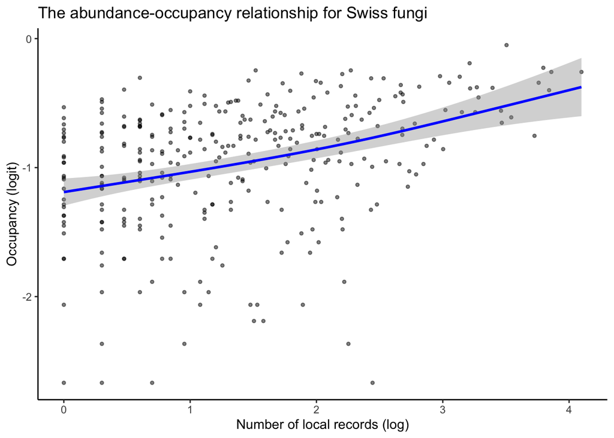

```r
> # Prepare data for abundance-occupancy relationship for Swiss data
> Swiss_data$log_local_abundance <- log10(Swiss_data$count)
> Swiss_data$logit_national_occupancy <- Swiss_data$logit_National_grid  # Using the pre-calculated logit value
>
> # Plot Swiss abundance-occupancy relationship (Figure 5b)
> swiss_ao_plot <- ggplot(Swiss_data, aes(x = log_local_abundance, y = logit_national_occupancy)) +
+   geom_point(alpha = 0.5, size = 1) +
+   geom_smooth(method = "gam", formula = y ~ s(x), color = "blue") +
+   labs(title = "The abundance-occupancy relationship for Swiss fungi",
+        x = "Number of local records (log)",
+        y = "Occupancy (logit)") +
+   theme_classic()
>
> print(swiss_ao_plot)
```

```r
> # Models for Swiss data
> Swiss_ao_linear <- lm(logit_national_occupancy ~ log_local_abundance, data = Swiss_data)
> Swiss_ao_gam <- gam(logit_national_occupancy ~ s(log_local_abundance), data = Swiss_data)
>
> # Compare R² values for Swiss data
> cat("Swiss Linear model R²:", summary(Swiss_ao_linear)$r.squared, "\n")
```

```
## Swiss Linear model R²: 0.1285939
```

```r
> cat("Swiss GAM model R²:", summary(Swiss_ao_gam)$r.sq, "\n")
```

```
## Swiss GAM model R²: 0.1286156
```

##### Original Figure

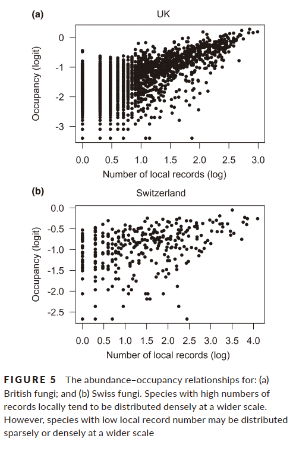

### Analysis 3: Multiscale Indices of Rarity (Figure 6)

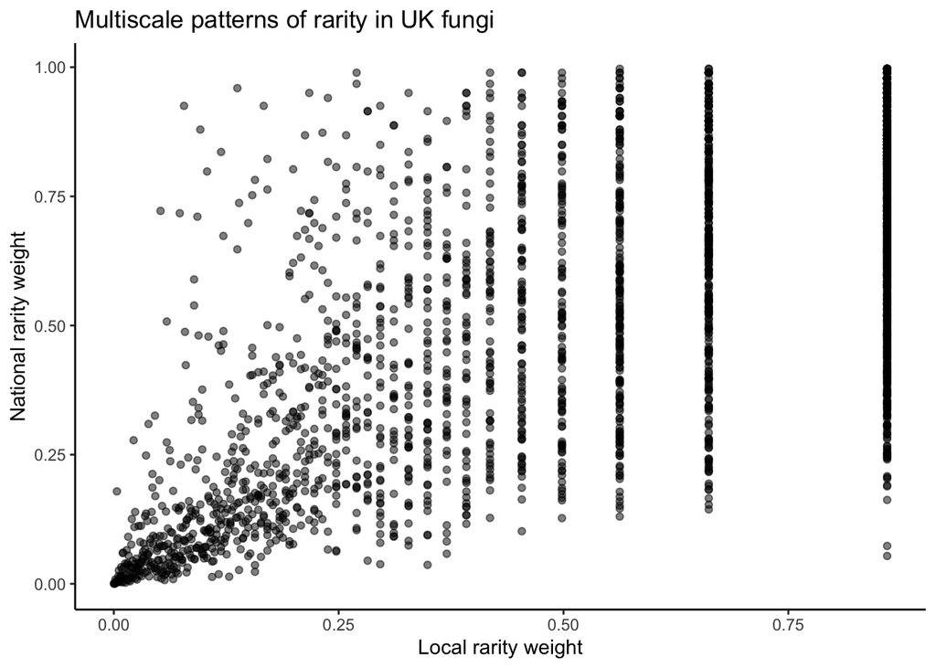

```r
> # Calculate quartile cutoff values (25th percentile) for UK data
> uk_local_cutoff <- quantile(UK_data$count, 0.25)
> uk_national_cutoff <- quantile(UK_data$FRDBI_count, 0.25)
>
> # Create rarity weights for UK data (scaled 0-1, higher = more rare)
> UK_data$local_rarity <- 1 - (rank(UK_data$count) / nrow(UK_data))
> UK_data$national_rarity <- 1 - (rank(UK_data$FRDBI_count) / nrow(UK_data))
>
> # Plot UK multiscale rarity (Figure 6a)
> uk_rarity_plot <- ggplot(UK_data, aes(x = local_rarity, y = national_rarity)) +
+   geom_point(alpha = 0.5) +
+   labs(title = "Multiscale patterns of rarity in UK fungi",
+        x = "Local rarity weight",
+        y = "National rarity weight") +
+   theme_classic()
>
> print(uk_rarity_plot)
```

```r
> # Calculate the relationship
> UK_rarity_model <- lm(national_rarity ~ local_rarity, data = UK_data)
> summary(UK_rarity_model)
```

```
##
## Call:
## lm(formula = national_rarity ~ local_rarity, data = UK_data)
##
## Residuals:
##      Min       1Q   Median       3Q      Max
## -0.68685 -0.15637 -0.02665  0.15532  0.70763
##
## Coefficients:
##              Estimate Std. Error t value Pr(>|t|)
## (Intercept)  0.165317   0.009081   18.21   <2e-16 ***
## local_rarity 0.669224   0.015781   42.41   <2e-16 ***
## ---
## Signif. codes:  0 '***' 0.001 '**' 0.01 '*' 0.05 '.' 0.1 ' ' 1
##
## Residual standard error: 0.2167 on 2317 degrees of freedom
## Multiple R-squared:  0.437,  Adjusted R-squared:  0.4367
## F-statistic:  1798 on 1 and 2317 DF,  p-value: < 2.2e-16
```

```r
> # Calculate proportion of species in different rarity categories
> # Using the cutoff values (25th percentile)
> UK_rare_local <- sum(UK_data$count <= uk_local_cutoff) / nrow(UK_data)
> UK_rare_national <- sum(UK_data$FRDBI_count <= uk_national_cutoff) / nrow(UK_data)
> UK_rare_both <- sum(UK_data$count <= uk_local_cutoff &
+                    UK_data$FRDBI_count <= uk_national_cutoff) / nrow(UK_data)
> UK_common_both <- sum(UK_data$count > uk_local_cutoff &
+                      UK_data$FRDBI_count > uk_national_cutoff) / nrow(UK_data)
> UK_rare_local_common_national <- sum(UK_data$count <= uk_local_cutoff &
+                                     UK_data$FRDBI_count > uk_national_cutoff) / nrow(UK_data)
> UK_common_local_rare_national <- sum(UK_data$count > uk_local_cutoff &
+                                     UK_data$FRDBI_count <= uk_national_cutoff) / nrow(UK_data)
>
> # Create table similar to Table 1 in the paper
> UK_rarity_table <- data.frame(
+   Category = c("Rare at both scales", "Common at both scales",
+                "Rare local, common national", "Common local, rare national"),
+   Percentage = c(UK_rare_both, UK_common_both,
+                  UK_rare_local_common_national, UK_common_local_rare_national) * 100
+ )
> print(UK_rarity_table)
```

```
##                      Category Percentage
## 1         Rare at both scales   13.62656
## 2       Common at both scales   60.06900
## 3 Rare local, common national   14.35964
## 4 Common local, rare national   11.94480
```

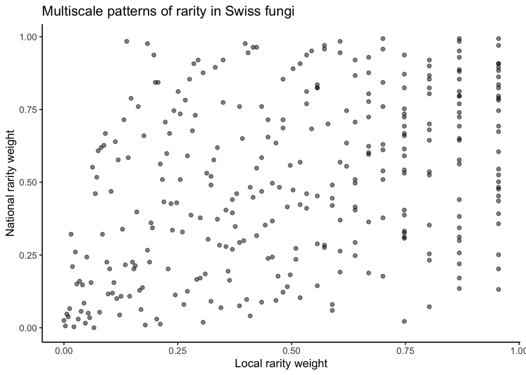

```r
> # Repeat for Swiss data
> swiss_local_cutoff <- quantile(Swiss_data$count, 0.25)
> swiss_national_cutoff <- quantile(Swiss_data$National_count, 0.25)
>
> Swiss_data$local_rarity <- 1 - (rank(Swiss_data$count) / nrow(Swiss_data))
> Swiss_data$national_rarity <- 1 - (rank(Swiss_data$National_count) / nrow(Swiss_data))
>
> # Plot Swiss multiscale rarity
> swiss_rarity_plot <- ggplot(Swiss_data, aes(x = local_rarity, y = national_rarity)) +
+   geom_point(alpha = 0.5) +
+   labs(title = "Multiscale patterns of rarity in Swiss fungi",
+        x = "Local rarity weight",
+        y = "National rarity weight") +
+   theme_classic()
>
> print(swiss_rarity_plot)
```

```r
> # Calculate Swiss rarity categories
> Swiss_rare_both <- sum(Swiss_data$count <= swiss_local_cutoff &
+                       Swiss_data$National_count <= swiss_national_cutoff) / nrow(Swiss_data)
> Swiss_common_both <- sum(Swiss_data$count > swiss_local_cutoff &
+                         Swiss_data$National_count > swiss_national_cutoff) / nrow(Swiss_data)
> Swiss_rare_local_common_national <- sum(Swiss_data$count <= swiss_local_cutoff &
+                                        Swiss_data$National_count > swiss_national_cutoff) / nrow(Swiss_data)
> Swiss_common_local_rare_national <- sum(Swiss_data$count > swiss_local_cutoff &
+                                        Swiss_data$National_count <= swiss_national_cutoff) / nrow(Swiss_data)
>
> # Create Swiss rarity table
> Swiss_rarity_table <- data.frame(
+   Category = c("Rare at both scales", "Common at both scales",
+                "Rare local, common national", "Common local, rare national"),
+   Percentage = c(Swiss_rare_both, Swiss_common_both,
+                  Swiss_rare_local_common_national, Swiss_common_local_rare_national) * 100
+ )
> print(Swiss_rarity_table)
```

```
##                      Category Percentage
## 1         Rare at both scales   10.65831
## 2       Common at both scales   56.73981
## 3 Rare local, common national   17.55486
## 4 Common local, rare national   15.04702
```

##### Original Figure

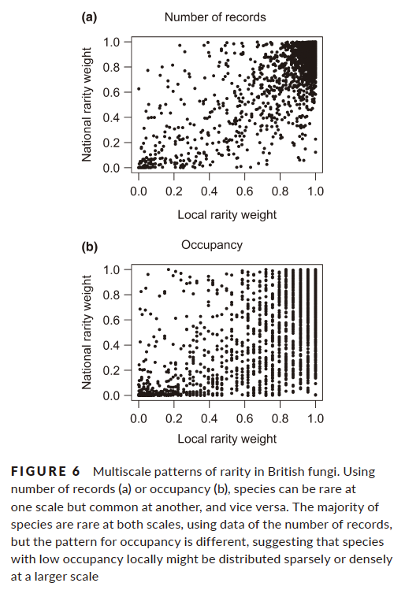